# Can Machine Learning Replace Wine Raters?

Amanda Markovitz and Elizabeth Welch

December 11, 2017

## Motivation

Being comfortable ordering a fine bottle of wine at a business lunch or selecting an appropriate bottle of wine as a gift is both a skill and an art form. It is nuanced – one needs enough savvy and sophistication to prevent social awkwardness but not so much that there is an air of pretension. And, everyone is always in search of that elusive wine that is a great deal – high quality for its price. This selection process very often relies on the perspectives of “experts”. However, are professional tasters/raters really worth their esteem and their salaries? Or, could the arguably “best” wines actually be predicted from algorithms built using publicly accessible data?

**Inspiration**

1. Our curiosity was initially piqued by reading about [Vivino](https://www.vivino.com/app), an app which targets ordinary people and guides them through choosing wines with a few finger taps. Vivino’s rapidly growing database (of over 3 million wines based on the contributions of over 6 million) attests to its filling a much-needed niche.
2. The various class lectures on machine learning gave us a glimpse of its power as a predictive tool and its potential as an ultimate replacement for many types of routine human work.

**Project Goal**

Our primary aim was to get hands-on practice dealing with true “big data” – large in dimension, untidy in format, with missingness, and eventually needing to be merged with one or more other data sets in order to answer a given scientific question. As such, we chose something that we knew would be conceptually interesting and yet intellectually challenging.

**Research Questions**

1. What factors are most significantly associated with wine quality (with “quality” defined based on expert rating)?
2. Are certain climate trends (extreme temperatures and considerable rainfall) during the wine’s harvesting season important determinants of wine quality?
3. Do you “get what you pay for” when you buy an expensive bottle of wine?
4. Can a machine learning algorithm be built that could predict wine quality as effectively as expert tasters/raters?

This last question evolved over the past couple of weeks. At the outset, we intended to use a data set involving non-experts’ ratings in order to do our predictive machine learning; we had to shift our plan when we realized that our identified data set was not publicly accessible.

## Data

**Sources of Data**

We collected our main data set from [Kaggle](https://www.kaggle.com/zynicide/wine-reviews), which included information on 129,971 wines. Notably, the Kaggle user had recently scraped from Wine Enthusiast. The outcome variable was points (i.e. expert’s rating, on a scale from 0 to 100). Important predictor variables included some geographic ones (country, province, and up to two regions), price, title (in which vintage year was embedded), and variety.

Additionally, since weather can influence wine quality, we gathered climate data from the [National Centers for Environmental Information National Ocean and Atmospheric Association](https://www.ncdc.noaa.gov/IPS/mcdw/mcdw.html). Specifically, we found records of daily mean temperature and daily precipitation for weather stations around the world.

**Data Scraping and Cleaning**

The first step entailed getting vintage year for each wine, and we data scraped from the title column of the original data set, extracting numbers from the strings. There were 4,662 wines for which we could not get this information; these years were entered as NAs.

Next, we needed the latitude and longitude coordinates for the region (or, when that could not be matched to coordinates, for the province) containing the vineyard where each wine was made. This geocoding was done using R’s geonames package. We verified the accuracy of this process by checking that the country codes produced by geocoding corresponded to the countries in the data set. The match rate was 71%.

We proceeded to find the closest global weather station (named “stationID”) associated with each latitude, longitude coordinate pair. This was done using R’s rnoaa package.

At this point, we filtered our data set to include only red wines that also had coordinates/station IDs. The resultant subset had 53,126 wines.

Last, we scraped from the climate data set to pull the daily mean temperature and daily precipitation measures. Based on our [background reading](http://winefolly.com/tutorial/start-planning-now-wine-harvest-season/), we learned that the harvesting season for vineyards in the northern hemisphere runs from August through October and for those in the southern hemisphere from February through April. After classifying each wine according to its hemisphere, we took averages over all recorded days of mean temperature and total rainfall within the appropriate three-month period in each wine’s particular vintage year. For 69% of wines, climate information was not available, in which case the indices were entered as 999s.

Upon filtering to rows with no missing values, our final, cleaned-up data set had 16,315 red wines. This was the data set used for machine learning analyses. Descriptive analyses and data visualizations were performed using the data set of 53,126 red wines.

### Identifying the Vintage Year

```r
##Load packages
library(stringr)
library(dplyr)

##Read in the dataset
wine <- read.csv("winemag-data-130k-v2.csv")

##Identify the wine vintage from the wine title
pattern <- "\\d\\d\\d\\d" #for the 4 digits that represent year
x <- str_detect(wine$title, pattern) #to look at x and find out how much missing data there were
length(wine$X) - sum(x) #4609 wines lack year
```

```
## [1] 4609
```

```r
wine$year <- str_extract(wine$title, pattern)

##look at the fields for wines that are missing year to make sure there isn't other information we could use
missing <- wine %>% filter(str_detect(title, pattern)!=1)
# head(missing, n=100)
##I didn't notice any years here, but I did notice they were mostly sparkling/champagne wines that were missing year, which we will probably want to exclude anyway

##Are there any values that seem unusual?
# wine %>% filter(year<1990 | year>2017)
##From the titles I noticed that sometimes they have other numbers which seem to often be the year the winery opened or sometimes are just part of the name of the wine

##It seems like only years from 1985(ish)-2017 are actually vintage years. Here's a second try at identifying the year based on this insight.
validyears <- as.character(seq(1985, 2017, by=1))
wine$year <- str_extract(wine$title, paste(validyears, collapse="|"))
# table(wine$year)
# wine %>% filter(is.na(wine$year))
##There are 4,662 missing vintage
```

### Geocoding the wine region

We will need to know the region in terms of longitude and latitude in order to map this information and link to external data sources with weather information. The geonames package seems to be the best free datasource out there with this type of information.

```r
##Installing any packages needed for geocoding
if(!require(mapproj)){
    install.packages("mapproj")
    library(mapproj)
}

if(!require(ggmap)){
    install.packages("ggmap")
    library(ggmap)
}

if(!require(rworldmap)){
    install.packages("rworldmap")
    library(rworldmap)
}

if(!require(sp)){
    install.packages("sp")
    library(sp)
}

if(!require(countrycode)){
    install.packages("countrycode")
    library(countrycode)
}

if(!require(geonames)){
    install.packages("geonames")
    library(geonames)
}

##from the wines dataset, select unique values of the region variable

regions <- as.data.frame(as.character(unique(wine$region_1)))
colnames(regions) <- c("region_1")
regions <- regions %>% filter(is.na(region_1)==FALSE & region_1!="")
#nrow(regions)

##Geocode the regions
##NOTE: Don't run this code unless you need to recreate the table of coordinates. Google have limits for the number of queries. I ran this once and saved it as an R file
# empty = as.data.frame(matrix(rep(NA,3), ncol = 3))
# colnames(empty) = c("longitude", "latitude", "address")
#
# geo = sapply(1:nrow(regions), function(x){
#   charregion <- as.character(regions[x,])
#   geo_result = tryCatch(geocode(charregion, output = 'latlona'),
#            error = function(e) {empty})
#  if (length(geo_result) !=3)
#  {
#    return(empty)
#  }
#    else(return(geo_result))
#   })
#
# geo = t(geo) %>% as.data.frame() %>% mutate(region_1 = regions$region_1)
#
# save(geo, file="geo.RData")

load(file="geo.RData")

##Now check whether this geocoding worked by seeing if these addresses match the country in the wines dataset

## Step 1: Join those latitude and longitude coordinates to a country ID (function sourced from https://stackoverflow.com/questions/14334970/convert-latitude-and-longitude-coordinates-to-country-name-in-r)

coords2country = function(points)
{
  countriesSP <- getMap(resolution='low')

  #setting CRS directly to that from rworldmap
  pointsSP <- SpatialPoints(points, proj4string=CRS(proj4string(countriesSP)))

  # use 'over' to get indices of the Polygons object containing each point
  indices <- over(pointsSP, countriesSP)

  # return the ISO3 names of each country
  indices$ISO3
}

##Feed this function a dataset called "points" with the long and lat as the 2 columns

geo <- geo %>% filter(is.na(longitude)==FALSE) %>% ##filter unmatched rows
  mutate(longitude=as.numeric(longitude), latitude=as.numeric(latitude))

points <- geo %>%  select(longitude, latitude)

geo$countryISO3 <- coords2country(points)

##Step 2: get a country code for the rows in the wines dataset

##Set options for the geonames package
###Set username (I created a profile on the website http://www.geonames.org/)
options(geonamesUsername="bi0260finalproject")
###Set api
options(geonamesHost="api.geonames.org")
###check that connection is working (some samples should pop up)
#source(system.file("tests","testing.R",package="geonames"),echo=TRUE)

##Add a column with the three character country code
wine$countryISO3 <- countrycode(ifelse(wine$country=="England", "United Kingdom", as.character(wine$country)), 'country.name', 'iso3c')

##Step 3: Join on the lat and long coordinates by region name and check that the countries match

wine_v2 <- left_join(wine, geo, by="region_1")

unmatched <- wine_v2 %>%
  filter(is.na(longitude)==TRUE | countryISO3.x!=countryISO3.y)

nrow(wine_v2)
```

```
## [1] 129971
```

```r
nrow(unmatched)
```

```
## [1] 61365
```

```r
##Fix the latitude and longitude fields to be NA when the countries don't match
wine_v2 <- wine_v2 %>%
  mutate(longitude=ifelse(countryISO3.x==countryISO3.y, longitude, NA)) %>%
  mutate(latitude=ifelse(countryISO3.x==countryISO3.y, latitude, NA))

##Now for all the unmatched, try to match to coordinates based on province instead

provinces <- as.data.frame(as.character(unique(unmatched$province)))
colnames(provinces) <- c("province")
provinces <- provinces %>% filter(is.na(province)==FALSE & province!="")
nrow(provinces)
```

```
## [1] 409
```

```r
##Geocode the regions
##NOTE: Don't run this code unless you need to recreate the table of coordinates. Google have limits for the number of queries. We ran this once and saved it as an R file
# empty = as.data.frame(matrix(rep(NA,3), ncol = 3))
# colnames(empty) = c("longitude", "latitude", "address")
#
# geo2 = sapply(1:nrow(provinces), function(x){
#   charprovince <- as.character(provinces[x,])
#   geo_result = tryCatch(geocode(charprovince, output = 'latlona'),
#            error = function(e) {empty})
#  if (length(geo_result) !=3)
#  {
#    return(empty)
#  }
#    else(return(geo_result))
#   })
#
# geo2 = t(geo2) %>% as.data.frame() %>% mutate(province = provinces$province)
#
# save(geo2, file="geo2.RData")

load(file="geo2.RData")

##Now check whether this geocoding worked by seeing if these addresses match the country in the wines dataset

## Step 1: Join those latitude and longitude coordinates to a country ID function
##Feed the function above into a dataset called "points" with the long and lat as the 2 columns

geo2 <- geo2 %>% filter(is.na(lon)==FALSE) %>% ##filter unmatched rows
  mutate(longitude=as.numeric(lon), latitude=as.numeric(lat))

points2 <- geo2 %>%  select(longitude, latitude)

geo2$countryISO3.z <- coords2country(points2)
 head(geo2)
```

```
##         lon      lat                                              address
## 1  14.01536 37.59999                                        sicily, italy
## 2 -5.492255 41.51202                                          douro river
## 3 -85.60236 44.31484                                        michigan, usa
## 4 -2.928907 43.26356 mazarredo zumarkalea, 8, 48001 bilbo, bizkaia, spain
## 5  7.441624 48.31818                                       alsace, france
## 6   8.08503 49.89353                    jugenheim in rheinhessen, germany
##            province  longitude latitude countryISO3.z
## 1 Sicily & Sardinia  14.015356 37.59999           ITA
## 2             Douro  -5.492255 41.51202           ESP
## 3          Michigan -85.602364 44.31484           USA
## 4    Northern Spain  -2.928907 43.26356           ESP
## 5            Alsace   7.441624 48.31818           FRA
## 6       Rheinhessen   8.085030 49.89353           DEU
```

```r
##Step 2: Join on the lat and long coordinates by province name and check that the countries match

wine_v3 <- left_join(wine_v2, geo2, by="province")

unmatched2 <- wine_v3 %>%
  mutate(longitude=ifelse(is.na(longitude.x)==FALSE,longitude.x, longitude.y )) %>%
  mutate(latitude=ifelse(is.na(latitude.x)==FALSE,latitude.x, latitude.y )) %>%
  filter(is.na(longitude)==TRUE | countryISO3.x!=countryISO3.z)

# nrow(wine_v3)
# nrow(unmatched2)
##We successfully matched 71%

wine_v3 <- wine_v3 %>%
  mutate(longitude=ifelse(is.na(longitude.x)==TRUE &
                            countryISO3.x==countryISO3.z,
                          longitude.y,
                          longitude.x)) %>%
  mutate(latitude=ifelse(is.na(latitude.x)==TRUE &
                            countryISO3.x==countryISO3.z,
                          latitude.y,
                          latitude.x)) %>%
  select(X, country, designation, points, price, province, region_1, region_2, taster_name, title, variety, winery, year, countryISO3.x, longitude, latitude)
```

### Linking to Climate Data

```r
if(!require(rnoaa)){
    install.packages("rnoaa")
    library(rnoaa)
}
# station_data <- ghcnd_stations()

#install pbapply to add a progress bar to the *apply functions and check their progress (very important when code takes many hours to run)
if(!require(pbapply)){
    install.packages("pbapply")
    library(pbapply)
}

##Restrict to just red wines and ones with coordinates (this helped the dataset be a somewhat more manageable size)

redwines <- c("Zinfandel", "Merlot", "Malbec", "Syrah", "Shiraz", "Sangiovese", "Cabernet Sauvignon", "Pinot Noir", "Barbera", "Aglianico", "Tinto Fino", "Tinta de Toro", "Tempranillo Blend", "Tempranillo", "Tannat", "Sangiovese", "Sangiovese Grosso", "Red Blend", "Rhône-style Red Blend", "Primitivo", "Portuguese Red", "Petite Sirah", "Petit Verdot", "Nero d'Avola", "Nerello Mascalese", "Nebbiolo", "Mourvèdre", "Monastrell", "Meritage", "Menc?a", "Malbec-Merlot", "Grenache", "Garnacha", "Gamay", "Corvina, Rondinella, Molinara", "Carmenère", "Cabernet Franc", "Bordeaux-style Red Blend", "Bonarda", "Barbera", "Aglianico")

wine_v4 <- wine_v3 %>% filter(is.na(longitude) == FALSE & variety %in% redwines)

#Obtain the closest weather station id based on latitude and longitude coordinates
##NOTE: Don't run this code unless you need to recreate the tables. We ran this code in batches and then rbind'ed them together. In total, this would take about 5-10 hours depending on your connection speed.
#
# lat_lon_dfinput <- wine_v4 %>% mutate(id=X) %>% select(id, latitude, longitude)
#
#
# stationids <-  pbsapply(1:nrow(lat_lon_dfinput), function(x) {
#   output <- meteo_nearby_stations(lat_lon_df=lat_lon_dfinput[x,],
#                           station_data = station_data, limit = 1)
#   output[[1]][1]
# }) %>% t()
#
# wine_v5 <- wine_v4 %>%
#   mutate(stationid = as.character(stationids[1,])) %>%
#   select(X, stationid)
#
# ##inner join back to the wine_v4
#
# wine_v6 <- inner_join(wine_v4, wine_v5, by="X")
#
# #getting min and max dates for growing seasons based on hemispheres
# minmonth <- ifelse(wine_v6$latitude>0,"08","02")
# wine_v6$min <- as.Date(paste(wine_v6$year, minmonth, "01", sep="-"), "%Y-%m-%d")
# maxmonth <- ifelse(wine_v6$latitude>0,"10","04")
# maxday <- ifelse(wine_v6$latitude>0, "31", "30")
# wine_v6$max <- as.Date(paste(wine_v6$year, maxmonth, maxday ,sep="-"), "%Y-%m-%d")
#
# #Obtain the average precipitation and temperature for this date range and weather station combination.
# #precip is in tenths of mm, tempavg is in tenths of degrees C
##NOTE: Don't run this code unless you need to recreate the tables. We ran this code in batches and then rbind'ed them together. In total, this would take about 20 hours- 1.5 days depending on your connection speed.
#
# empty = matrix(rep(999,2), nrow = 1)
# f = pbsapply(1:nrow(wine_v6), function(x) {
#   tryCatch(meteo_tidy_ghcnd(as.character(wine_v6$stationid[x]),
#                      keep_flags = FALSE,
#                      var = c("prcp","tavg"),
#                      date_min = as.character(wine_v6$min[x]),
#                      date_max = as.character(wine_v6$max[x])) %>%
#     # group_by(id) %>%
#     summarize(avgprcp=mean(prcp/10, na.rm=TRUE),
#             avgtemp=mean(tavg/10, na.rm=TRUE)), error = function(e) {empty})
#   }) %>% t() %>% as.data.frame()
#
# wine_v7 <- wine_v6 %>%
#   mutate(avgprcp = as.numeric(f$V1), avgtemp = as.numeric(f$V2), year = as.numeric(year))
#
# save(wine_v7, file="wine_v7.RData")

load(file="wine_v7.RData")
```

## Data Analysis

Data analysis for this project included descriptive analyses, data visualizations (including maps), and machine learning.

**Descriptive**

We began with some basic univariate analyses for continuous variables in our dataset: histograms for wine ratings, price, and years.

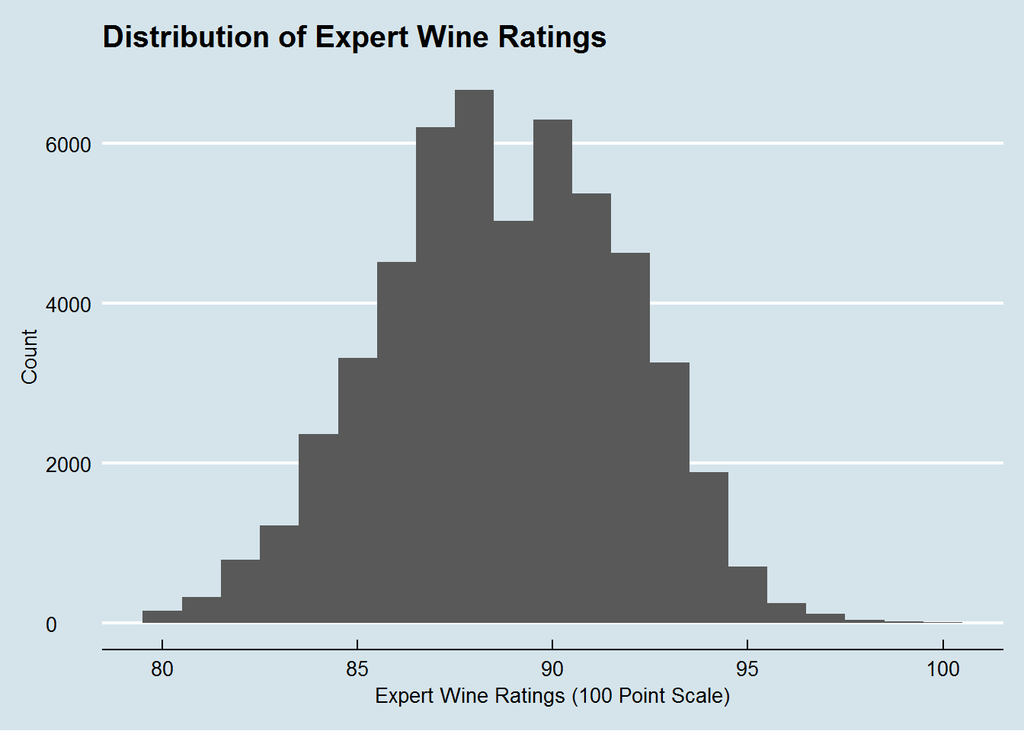

```r
if(!require(ggthemes)){
    install.packages("ggthemes")
    library(ggthemes)
}

##histogram for wine ratings
p <- wine_v4 %>%
  ggplot(aes(points)) +
  geom_histogram(binwidth = 1) +
  labs(y= "Count", x="Expert Wine Ratings (100 Point Scale)",title="Distribution of Expert Wine Ratings") +
  theme_economist()

# jpeg(filename="hist_ratings.jpg")
p
```

```r
# dev.off()

summary(wine_v4$points)
```

```
##    Min. 1st Qu.  Median    Mean 3rd Qu.    Max.
##   80.00   87.00   89.00   88.74   91.00  100.00
```

```r
sd(wine_v4$points)
```

```
## [1] 3.115525
```

The distribution of expert wine ratings is approximately normal, with a mean of 89 and a standard deviation of 3. Interestingly, although wine reviews are purportedly on a 100 point scale, scores in our dataset did not drop below 80. As graduate students, we know a little something about this type of “grade inflation”.

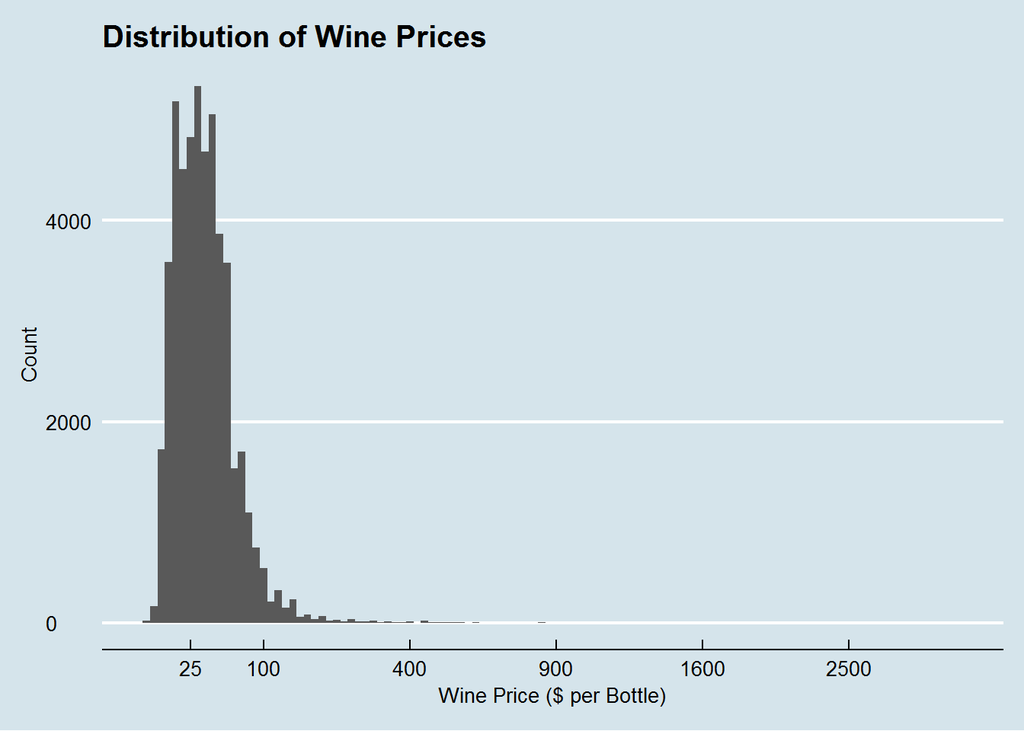

```r
##histogram for wine prices
p <- wine_v4 %>%
  ggplot(aes(price)) +
  geom_histogram(binwidth = 0.5) +
  labs(y= "Count", x="Wine Price ($ per Bottle)",title="Distribution of Wine Prices") +
  theme_economist()

# jpeg(filename="hist_prices.jpg", width = 710, height = 480)
  p + scale_x_continuous(trans = "sqrt", breaks = c(0, 25, 100, 400, 900, 1600, 2500))
```

```r
# dev.off()

summary(wine_v4$price)
```

```
##    Min. 1st Qu.  Median    Mean 3rd Qu.    Max.    NA's
##    4.00   20.00   32.00   40.21   50.00 3300.00    3541
```

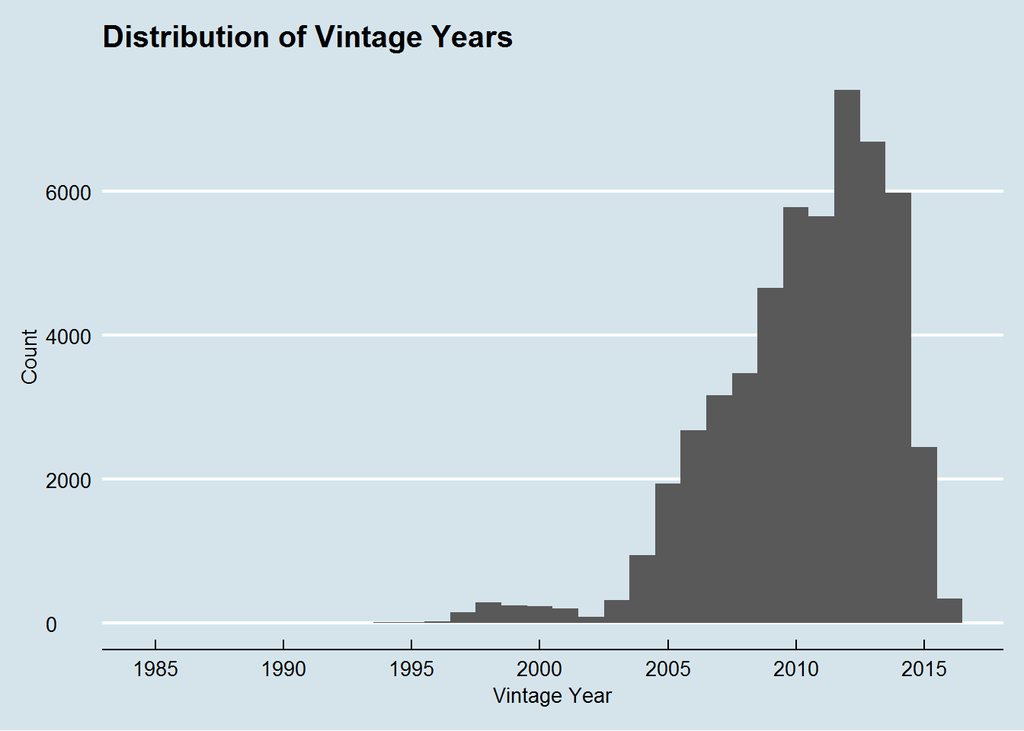

```r
##histogram for years
p <- wine_v4 %>%
  ggplot(aes(as.numeric(year))) +
  geom_histogram(binwidth = 1) +
  labs(y= "Count", x="Vintage Year",title="Distribution of Vintage Years") +
  theme_economist()

# jpeg(filename="hist_vintage.jpg", width = 710, height = 480)
  p + scale_x_continuous(breaks = c(1985, 1990, 1995, 2000, 2005, 2010, 2015))
```

```r
# dev.off()

summary(as.numeric(wine_v4$year))
```

```
##    Min. 1st Qu.  Median    Mean 3rd Qu.    Max.    NA's
##    1985    2008    2011    2010    2013    2016     406
```

We restricted to wine reviews from 1985 onward and there were no reviews beyond 2016 in the Kaggle dataset. The majority of reviews were from between 2005 and 2015.

**Data Visualizations**

Data visualizations include average rating by price (correlation plot), average ratings by type of wine (using boxplots), average ratings by country (using maps), average ratings by country and year (using the tile plots in R), average ratings by type of wine and year (using the tile plots in R), and average rating by precipitation and temperature (correlation plots).

We used data visualization to look at predictors of expert ratings in our dataset.

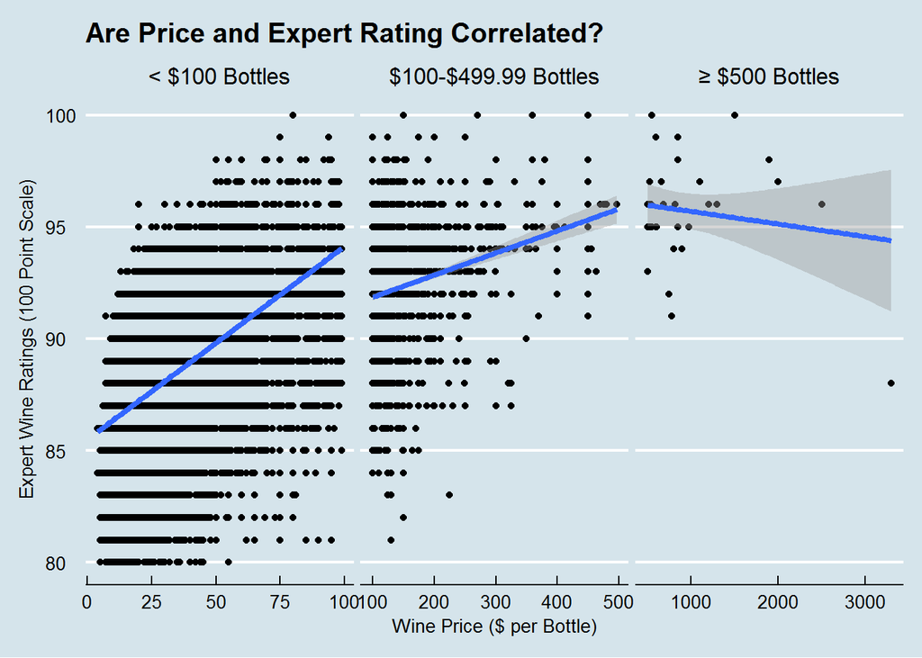

```r
##rating by price correlaton
##break this into categories of prices because otherwise the graph is too clumped to see correlations. We can also see from this that price makes a bigger difference in terms of ratings at lower prices and then no difference past $500
p <- wine_v4 %>%
  filter(is.na(price)==FALSE) %>%
  mutate(pricecat = ifelse(price<100, "< $100 Bottles", ifelse(price<500, "$100-$499.99 Bottles", "\u2265 $500 Bottles"))) %>%
  mutate(pricecat = reorder(pricecat, price, FUN = median)) %>%
  ggplot(aes(price, points)) +
  geom_point()  +
  facet_grid(. ~ pricecat, scales="free_x") +
  geom_smooth(method = "lm", size = 1.5) +
  labs(y= "Expert Wine Ratings (100 Point Scale)", x="Wine Price ($ per Bottle)",title="Are Price and Expert Rating Correlated?") +
  theme_economist()

# jpeg(filename="rating_byprice.jpg", width = 710, height = 480)
 p
```

```r
# dev.off()
```

First, we were interested to know if wine price predicted expert ratings. For the normal price range that the average consumer purchases (0-$100), price was highly predictive of quality, but this association was weaker for more expensive bottles and appeared to be non-existent for bottles over $500. Perhaps when you spend that much on a bottle, your expectations for how it will taste can be too high.

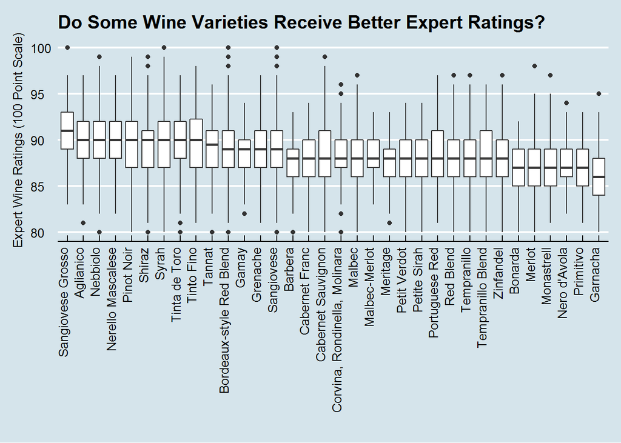

```r
##average ratings by wine type
p <- wine_v4 %>%
  mutate(variety = reorder(variety, -points, FUN = median)) %>%
  ggplot(aes(variety, points)) +
  geom_boxplot()  +
  labs(y= "Expert Wine Ratings (100 Point Scale)", x=" ",title="Do Some Wine Varieties Receive Better Expert Ratings?") +
  theme_economist() +
  theme(axis.text.x = element_text(angle = 90, hjust = 1))

# jpeg(filename="rating_byvariety.jpg", width = 710, height = 480)
  p
```

```r
# dev.off()
```

We also examined whether certain varieties of wines (or grapes) were preferred by raters. Sangiovese Grosso tended to be the highest rated and Garnacha the lowest rated, although there was considerable variability in ratings even within a single variety.

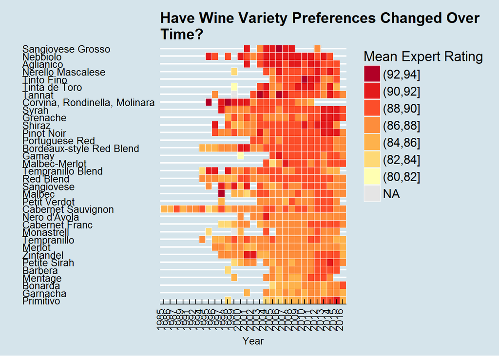

```r
##average ratings by variety and year
if(!require(RColorBrewer)){
    install.packages("RColorBrewer")
    library(RColorBrewer)
}
dat3 <- wine_v4 %>%
  filter(is.na(points)==FALSE & is.na(variety)==FALSE & is.na(year)==FALSE) %>%
  group_by(variety, year) %>%
  summarize(meanrating = mean(points), total.count=n()) %>%
  ungroup()

breaks <- seq(80, 94, by=2)
dat3$rating_rescale <- cut(dat3$meanrating,breaks = breaks)
dat3$rating_rescale <- factor(as.character(dat3$rating_rescale),
levels=rev(levels(dat3$rating_rescale)))


p <- dat3 %>% mutate(variety = reorder(variety, meanrating, FUN = median)) %>%
  ggplot(aes(year, variety)) + geom_tile(aes(fill = rating_rescale), colour = "white",size=0.25) +
  labs(x="Year",y="",title="Have Wine Variety Preferences Changed Over
Time?") +
  scale_y_discrete(expand=c(0,0)) +
  theme_economist() +
  theme(axis.text.x = element_text(angle = 90, hjust = 1), legend.position="right", legend.justification = c("left", "top"), legend.title = element_text(size=14)) +
  scale_fill_manual(values=rev(brewer.pal(7,"YlOrRd")),na.value="grey90", name="Mean Expert Rating") +
  guides(fill=guide_legend(ncol=1,bycol=TRUE))

# jpeg(filename="ratings_byvarietyyear.jpg", width = 710, height = 480)
p
```

```r
# dev.off()
```

**NOTE to Instructors and TAs: Although the next three blocks of code below ran through and we were able to create maps that were added to the website, when we tried to knit this file the next day, we received an error making the maps. We believe the rworldmap package was updated or for some other reason the identical code we ran the day before no longer works. We prevented it from running below so that it would not impact successfully knitting the rest of the document.**

```r
##average ratings by country
##Use the rworldmap package
if(!require(rworldmap)){
    install.packages("rworldmap")
    library(rworldmap)
}

###first, aggregate ratings data by country
dat <- wine_v4 %>%
  filter(is.na(points)==FALSE) %>%
  group_by(countryISO3.x, country) %>%
  summarize(meanrating = mean(points), meanprice = mean(price))

# dat %>% arrange(-meanrating) %>% select(country,countryISO3.x, meanrating)

###then, map these data
sPDF <- joinCountryData2Map(dat,
                            joinCode = "ISO3",
                            nameJoinColumn = "countryISO3.x")

mapDevice() #create world map shaped window


##across the world

# jpeg(filename="rating_bycountry.jpg", width = 710, height = 480)
mapCountryData(sPDF,
               nameColumnToPlot='meanrating',
               mapTitle='Mean Expert Wine Rating by Country')
# dev.off()
```

```r
##in Europe

# jpeg(filename="rating_byEurope.jpg", width = 710, height = 480)
mapCountryData(sPDF,
               nameColumnToPlot='meanrating',
               mapTitle='Mean Expert Wine Rating by Country in Europe',
               mapRegion="europe")
# dev.off()
```

```r
##Mean Prices by country (not shown on website)
##across the world
mapCountryData(sPDF,
               nameColumnToPlot='meanprice',
               mapTitle='Mean Wine Price by Country')

##in Europe
mapCountryData(sPDF,
               nameColumnToPlot='meanprice',
               mapTitle='Mean Wine Price by Country in Europe',
               mapRegion="europe")
```

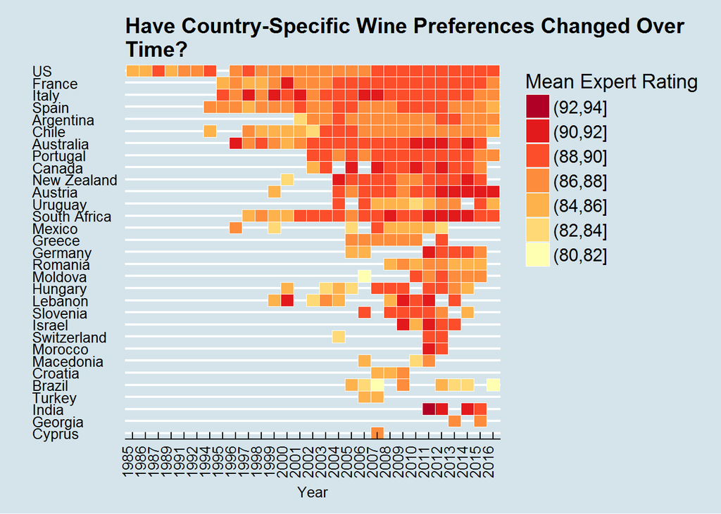

```r
##average ratings by country and year
dat2 <- wine_v4 %>%
  filter(is.na(points)==FALSE & is.na(year)==FALSE) %>%
  group_by(country, year) %>%
  summarize(meanrating = mean(points), total.count=n()) %>%
  ungroup()

breaks <- seq(80, 94, by=2)
dat2$rating_rescale <- cut(dat2$meanrating,breaks = breaks)
dat2$rating_rescale <- factor(as.character(dat2$rating_rescale),
levels=rev(levels(dat2$rating_rescale)))


p <- dat2 %>% mutate(country = reorder(country, total.count, FUN = max)) %>%
  ggplot(aes(year, country)) + geom_tile(aes(fill = rating_rescale), colour = "white",size=0.25) +
  labs(x="Year",y="",title="Have Country-Specific Wine Preferences Changed Over
Time?") +
  scale_y_discrete(expand=c(0,0)) +
  theme_economist() +
  theme(axis.text.x = element_text(angle = 90, hjust = 1), legend.position="right", legend.justification = c("left", "top"), legend.title = element_text(size=14)) +
  scale_fill_manual(values=rev(brewer.pal(7,"YlOrRd")),na.value="grey90", name="Mean Expert Rating") +
  guides(fill=guide_legend(ncol=1,bycol=TRUE))

# jpeg(filename="ratings_bycountryyear.jpg", width = 710, height = 480)
p
```

```r
# dev.off()
```

We were also curious if there were trends over time in these ratings. Although there weren’t reviews for every country and year combination, we did notice that countries like South Africa and Australia have really improved over time.

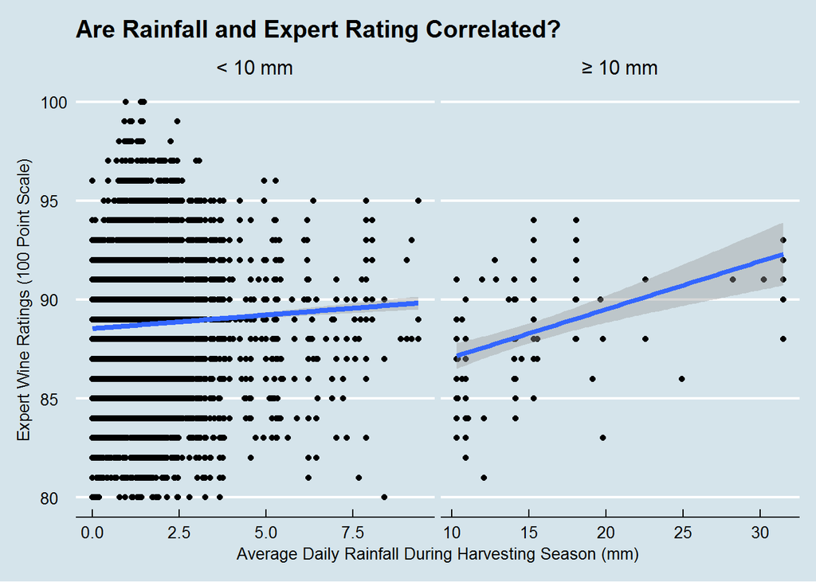

```r
##Correlation between average precipitation and wine rating
p <- wine_v7 %>%
  filter(avgprcp!=999) %>%
  mutate(raincat = ifelse(avgprcp<10, "< 10 mm", "\u2265 10 mm")) %>%
  mutate(raincat = reorder(raincat, avgprcp, FUN = median)) %>%
  ggplot(aes(avgprcp, points)) +
  geom_point()  +
  facet_grid(. ~ raincat, scales="free_x") +
  geom_smooth(method = "lm", size = 1.5) +
  labs(y= "Expert Wine Ratings (100 Point Scale)", x="Average Daily Rainfall During Harvesting Season (mm)",title="Are Rainfall and Expert Rating Correlated?") +
  theme_economist()

 # jpeg(filename="rating_byrain.jpg", width = 710, height = 480)
 p
```

```r
 # dev.off()
```

Usually you hear that drought is associated with better quality, but in our data set, we find that higher rainfall during the harvesting season is associated with better quality. It is possible that the relationship is more complex and may vary across wine type. The machine learning algorithm used (detailed in the next section) may better handle these types of relationships.

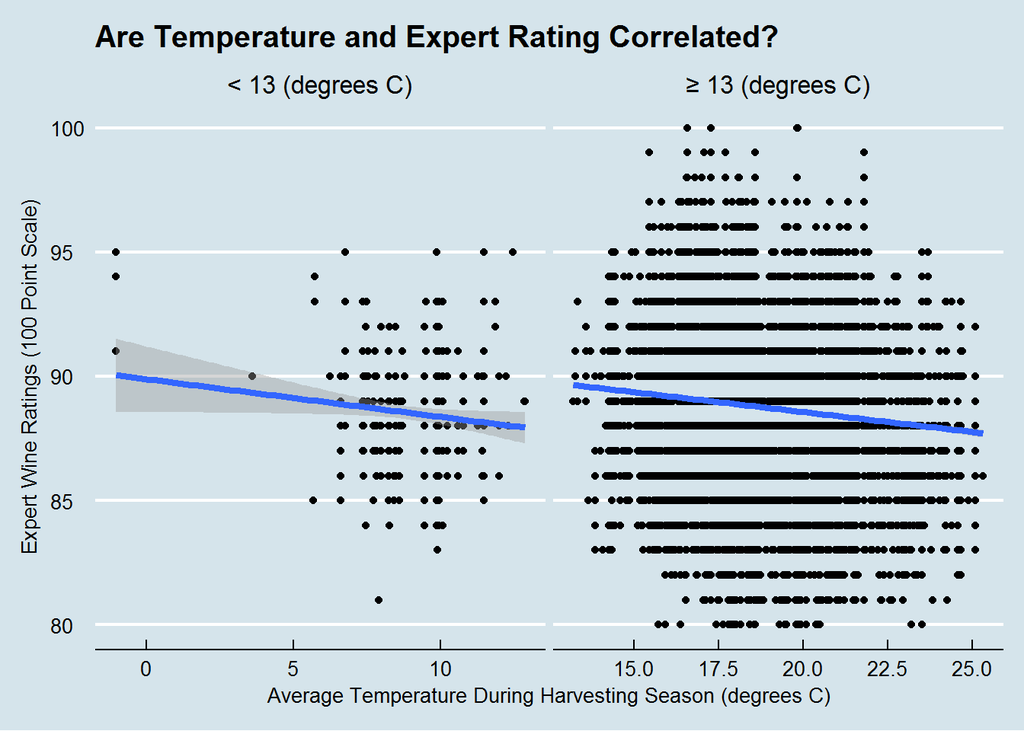

```r
 ##Correlation between average temperature and wine rating
p <- wine_v7 %>%
  filter(avgtemp!=999) %>%
  mutate(tempcat = ifelse(avgtemp<13, "< 13 (degrees C)", "\u2265 13 (degrees C)")) %>%
  mutate(tempcat = reorder(tempcat, avgtemp, FUN = median)) %>%
  ggplot(aes(avgtemp, points)) +
  geom_point()  +
  facet_grid(. ~ tempcat, scales="free_x") +
  geom_smooth(method = "lm", size = 1.5) +
  labs(y= "Expert Wine Ratings (100 Point Scale)", x="Average Temperature During Harvesting Season (degrees C)",title="Are Temperature and Expert Rating Correlated?") +
  theme_economist()

 # jpeg(filename="rating_bytemp.jpg", width = 710, height = 480)
 p
```

```r
 # dev.off()
```

The majority of wines are harvested in the 13-25 $^\circ$ Celsius range; however, some are successfully harvested in colder climates. It seems that colder climates are associated with better wine quality.

**Machine Learning**

We predicted wine ratings based on the other characteristics available in our dataset (including price, longitude, latitude, wine variety, year, precipitation, and temperature) using random forests.

```r
if(!require(randomForest)){
    install.packages("randomForest")
    library(randomForest)
}
if(!require(caret)){
    install.packages("caret")
    library(caret)
}
set.seed(658)

##Create a dataset with no missing information
##also, reset wine variety as factor because it current recognizes >700 levels of variety from the original dataset when there are now only 35 in our final dataset
wine_v7_ml <- wine_v7 %>%
  filter(avgtemp!=999 &
           avgprcp!=999 &
           is.na(points)==FALSE &
           is.na(price)==FALSE &
           is.na(longitude)==FALSE &
           is.na(variety)==FALSE &
           is.na(year)==FALSE) %>%
  mutate(variety = as.factor(as.character(variety)))

##rows in final dataset
nrow(wine_v7_ml)
```

```
## [1] 16315
```

```r
##Step 1: run a basic random forest to get started

fit <- randomForest(points ~ price + longitude + latitude  + variety +
                      year + avgtemp + avgprcp,
                      data=wine_v7_ml,
                      importance=TRUE,
                      ntree=500)

fit
```

```
##
## Call:
##  randomForest(formula = points ~ price + longitude + latitude +      variety + year + avgtemp + avgprcp, data = wine_v7_ml, importance = TRUE,      ntree = 500)
##                Type of random forest: regression
##                      Number of trees: 500
## No. of variables tried at each split: 2
##
##           Mean of squared residuals: 4.182082
##                     % Var explained: 53.65
```

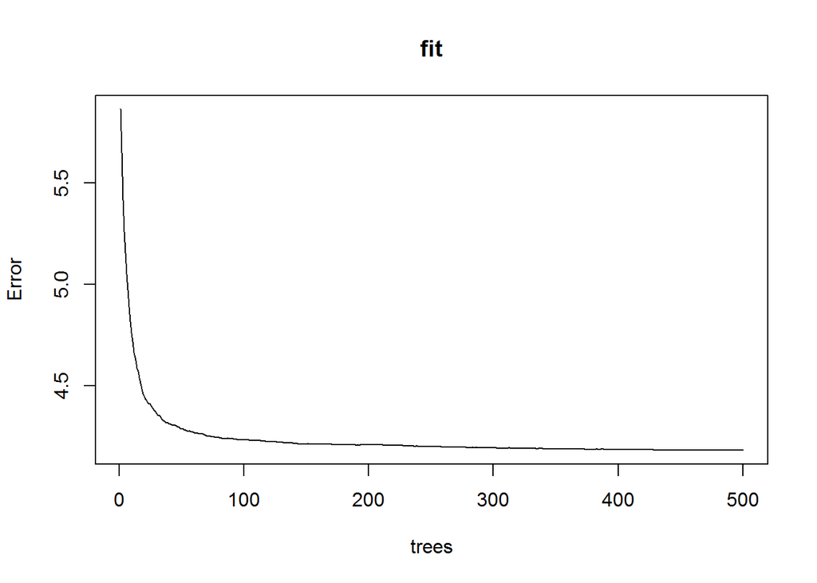

```r
##Step 2: decide how many trees need to be run
##plot fit to see how it improves with each tree
plot(fit)
```

```r
##identify the minimum mse by number of trees
which.min(fit$mse)
```

```
## [1] 484
```